# Assignment 1

Emma Colley

9/16/2020

# Introduction

## Loading Libraries

```r
library(tidyverse)
library(tidycensus)
library(ggplot2)
library(ggthemes)
```

## Defining Variables

Here are the six variables I selected. I will use these to experiment with different plots and figures:

*Categorical* 1. The majority racial/ethnic identity 2. Whether homeownership in the tract is majority white ownership or non-white ownership

*Continuous* 1. The population of the tract 2. Average household size 3. The percent of households who own their homes 4. The median age of residents

## Loading Variables and Data

I replicated the majority race/ethnicity variable from Carole’s tutorial and by doing so I learned to use the mutate function to create a new categorical variable about white homeownership vs. non-white homeownership. This will come up in several of the plots.

```r
area_vars_2010 <- load_variables(2010, "sf1")
```

```r
vars <- c(tot_hh = "H001001",
          tot_hh_owner = "H006001",
          hh_owner_white = "H006002",
         tot_own_mortgage_hh = "H004002",
         tot_own_clear_hh = "H004003",
         avg_hh_size = "H012001",
         tot_pop = "P003001",
         nh_white_pop = "P005003",
         nh_black_pop = "P005004",
         nh_asian_pop = "P005006",
         hispanic_pop = "P005010",
         med_age = "P013001")

SD_tracts <- get_decennial(geography = "tract", variables = vars,
                           state = "MA", county = "Suffolk",
                           output = "wide") %>%
mutate(pct_own = (tot_own_mortgage_hh + tot_own_clear_hh) / tot_hh,
         majority_white_ownership = case_when(
           hh_owner_white / tot_hh_owner > 0.5 ~ "TRUE",
           hh_owner_white / tot_hh_owner < 0.5 ~ "FALSE"),
         majority_race_eth = case_when(
           nh_white_pop / tot_pop > 0.5 ~ "nh_white",
           nh_black_pop / tot_pop > 0.5 ~ "nh_black",
           nh_asian_pop / tot_pop > 0.5 ~ "nh_asian",
           hispanic_pop / tot_pop > 0.5 ~ "hispanic",
           (nh_white_pop + nh_black_pop + nh_asian_pop + hispanic_pop) /
             tot_pop < 0.5 ~ "other",
           TRUE ~ "None")) %>%
  filter(tot_pop > 0, tot_hh > 0) %>%
  select(GEOID, majority_white_ownership, majority_race_eth,
         pct_own, avg_hh_size, tot_pop, med_age)
```

## Plot 1

This is a scatter plot that has a continuous variable on each axis and represents one categorical variable using color. In general, it looks like the higher the median age within a tract, the higher the percentage of homeowners.

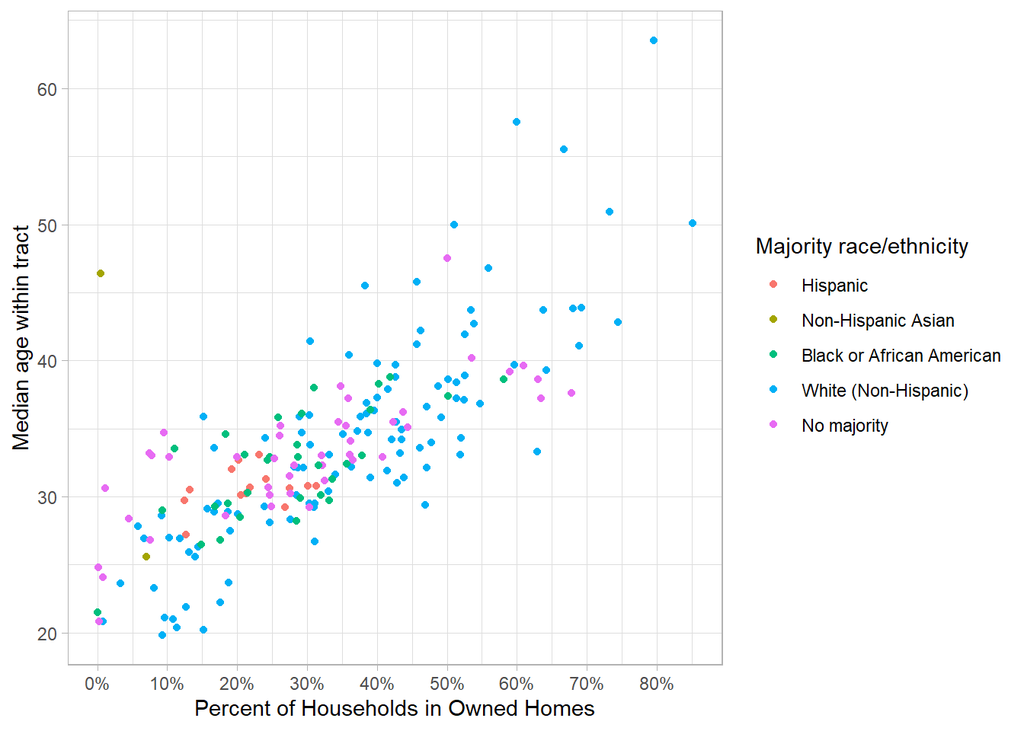

```r
ggplot(SD_tracts,
       aes(x = pct_own,
           y = med_age,
           color = majority_race_eth)) +
  geom_point() +
  scale_x_continuous(name = "Percent of Households in Owned Homes",
                     breaks = seq(0, 1, by = 0.1),
                     labels = paste(seq(0, 100, by = 10), "%", sep = "")) +
  scale_y_continuous(name = "Median age within tract",
                     breaks = seq(10, 80, by = 10)) +
  scale_color_discrete(name = "Majority race/ethnicity",
                       labels = c("Hispanic",
                                  "Non-Hispanic Asian",
                                  "Black or African American",
                                  "White (Non-Hispanic)",
                                  "No majority")) +
  theme_light()
```

## Plot 2

Here I introduced a trend line. I also changed the Y-axis variable to “Average Household Size”. It looks like tracts that are a majority white (non-Hispanic) have the lowest average household size.

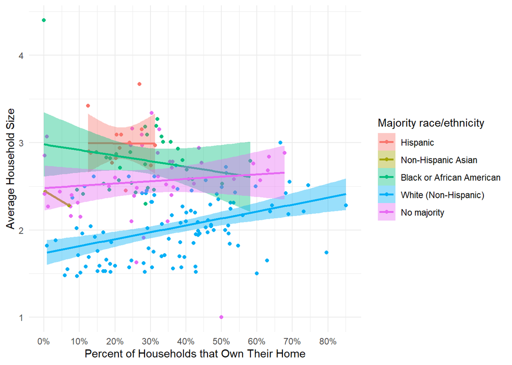

```r
ggplot(SD_tracts,
       aes(x = pct_own,
           y = avg_hh_size,
           color = majority_race_eth,
           fill = majority_race_eth)) +
  geom_point() +
  stat_smooth(method = "lm") +
  scale_x_continuous(name = "Percent of Households that Own Their Home",
                     breaks = seq(0, 1, by = 0.1),
                     labels = paste(seq(0, 100, by = 10), "%", sep = "")) +
  scale_y_continuous(name = "Average Household Size",
                     breaks = seq(1, 10, by = 1)) +
  scale_color_discrete(name = "Majority race/ethnicity",
                       labels = c("Hispanic",
                                  "Non-Hispanic Asian",
                                  "Black or African American",
                                  "White (Non-Hispanic)",
                                  "No majority")) +
  scale_fill_discrete(name = "Majority race/ethnicity",
                       labels = c("Hispanic",
                                  "Non-Hispanic Asian",
                                  "Black or African American",
                                  "White (Non-Hispanic)",
                                  "No majority")) +
  theme_minimal()
```

## Plot 3

Here is a scatter plot showing Track Population and the Percentage of Household that Own Their Home. This plot isn’t saying much, but here I was experimenting with ggthemes, which I’m still figuring out. Many of the aesthetically pleasing themes were causing me issue with X and Y axis labels.

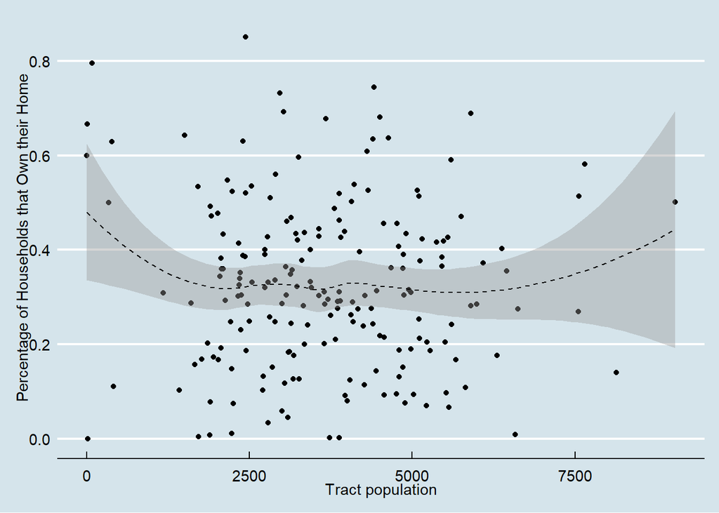

```r
ggplot(SD_tracts,
       aes(x = tot_pop,
           y = pct_own)) +
  geom_point() +
  stat_smooth(color = "black", linetype = 2, size = 0.5) +
  scale_x_continuous(name = "Tract population") +
  scale_y_continuous(name = "Percentage of Households that Own their Home") +
  theme_economist()
```

## Plot 4

Here I am representing a continuous and categorical variable with position. I used “jitter” and adjusted the color and size to better represent each data point. The relationship between average household size and majority race/ethnicity is interesting to me.

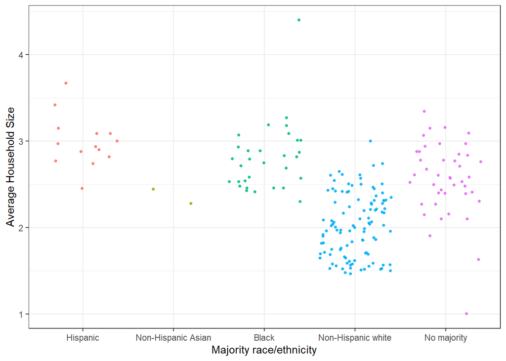

```r
ggplot(SD_tracts,
       aes(x = majority_race_eth,
           y = avg_hh_size,
           color = majority_race_eth)) +
  geom_point(position = "jitter",
             size = 1.0,
             alpha = 0.9) +
  scale_x_discrete(name = "Majority race/ethnicity",
                       labels = c("Hispanic",
                                  "Non-Hispanic Asian",
                                  "Black",
                                  "Non-Hispanic white",
                                  "No majority")) +
  scale_y_continuous(name = "Average Household Size",
                     breaks = seq(1, 10, by = 1)) +
  theme_bw() +
  theme(legend.position = "none")
```

## Plot 5

Here is a box plot. I experimented with flipping the x and y axis. I am also switching up the continuous variables again.

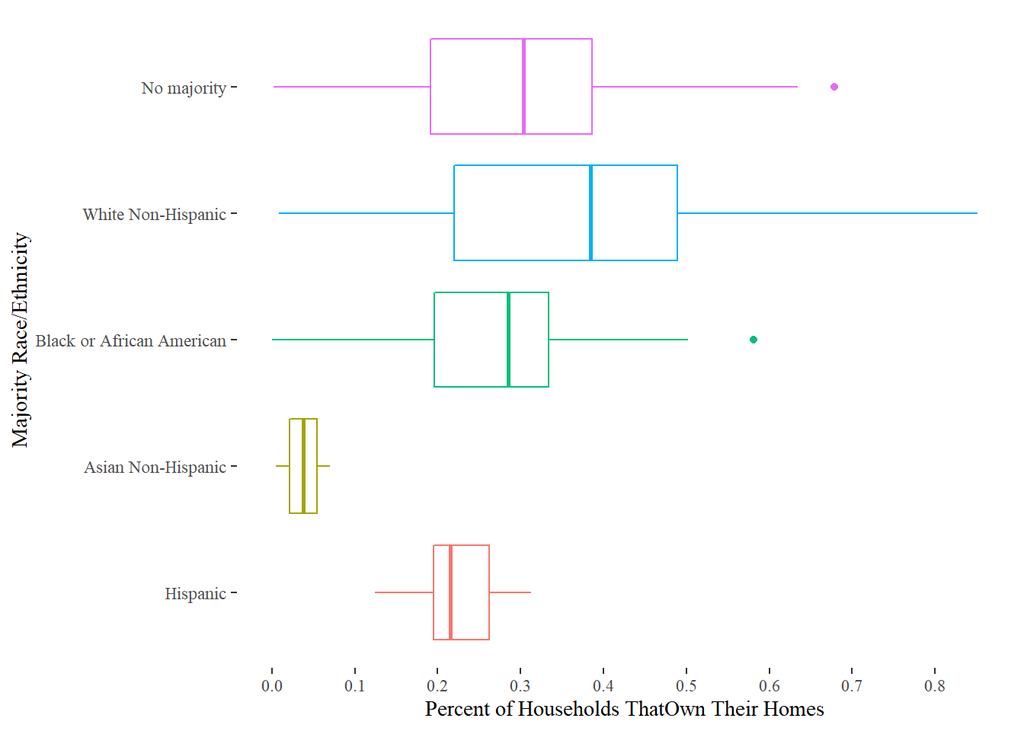

```r
ggplot(SD_tracts,
       aes(x = majority_race_eth,
           y = pct_own,
           color = majority_race_eth)) +
  geom_boxplot() +  coord_flip() +
  scale_x_discrete(name = "Majority Race/Ethnicity",
                       labels = c("Hispanic",
                                  "Asian Non-Hispanic",
                                  "Black or African American",
                                  "White Non-Hispanic",
                                  "No majority")) +
  scale_y_continuous(name = "Percent of Households ThatOwn Their Homes",
                     breaks = seq(0, 1, by = 0.1)) +
  theme_tufte() +
  theme(legend.position = "none")
```

## Plot 6

This is a violin plot with a scatter plot on top of it. I referenced Reuven’s code to add in a fill. This plot shows that tracts with a majority of white households have the largest spread of percentage of homeownership.

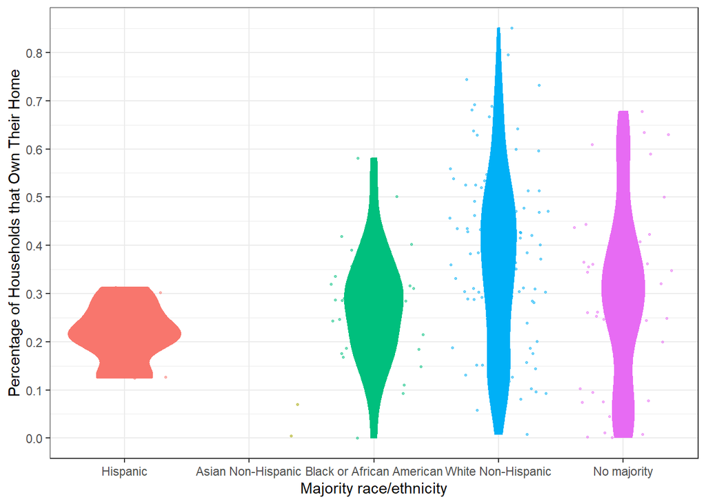

```r
ggplot(SD_tracts,
       aes(x = majority_race_eth,
           y = pct_own, fill = majority_race_eth,
           color = majority_race_eth)) +
  geom_violin() +
  geom_point(position = "jitter",
             alpha = 0.5,
             size = 0.5) +
  scale_x_discrete(name = "Majority race/ethnicity",
                       labels = c("Hispanic",
                                  "Asian Non-Hispanic",
                                  "Black or African American",
                                  "White Non-Hispanic",
                                  "No majority")) +
  scale_y_continuous(name = "Percentage of Households that Own Their Home",
                     breaks = seq(0, 1, by = 0.1)) +
  theme_bw() +
  theme(legend.position = "none")
```

## Plot 7

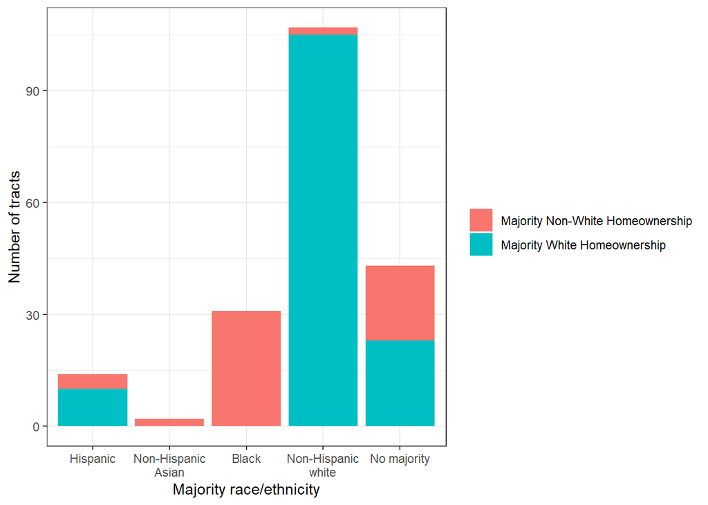

```r
ggplot(SD_tracts, aes(x = majority_race_eth, fill = majority_white_ownership)) +
  geom_bar() +
  scale_y_continuous(name = "Number of tracts") +
  scale_x_discrete(name = "Majority race/ethnicity",
                       labels = c("Hispanic",
                                  "Non-Hispanic\nAsian",
                                  "Black",
                                  "Non-Hispanic\nwhite",
                                  "No majority")) +
  scale_fill_discrete(name = element_blank(),
                        labels = c("Majority Non-White Homeownership",
                                   "Majority White Homeownership")) +
  theme_bw()
```

## Plot 8

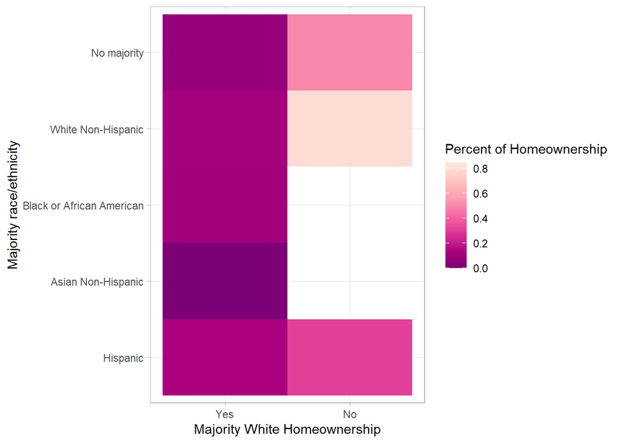

```r
ggplot(SD_tracts, aes(x = majority_race_eth, y = majority_white_ownership, fill = pct_own)) +
       geom_tile() + coord_flip() +
      scale_x_discrete(name = "Majority race/ethnicity",
                       labels = c("Hispanic",
                                  "Asian Non-Hispanic",
                                  "Black or African American",
                                  "White Non-Hispanic",
                                  "No majority")) +
      scale_y_discrete(name = "Majority White Homeownership",
                       labels = c("Yes",
                                  "No")) +
      scale_fill_distiller(palette = "RdPu") +
      labs(fill = "Percent of Homeownership") +
      theme_light()
```

## Plot 9

This is a pie chart. My next step will be to learn to edit the colors of this. I’m still confused by the ggplot cheatsheet.

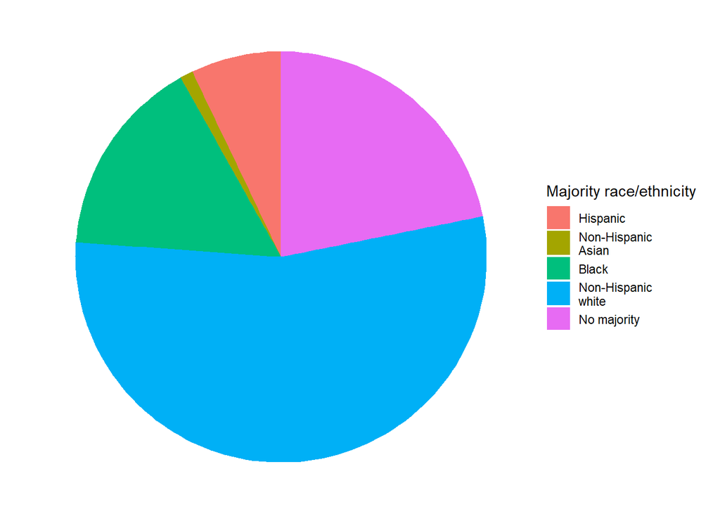

```r
pie_chart <- ggplot(SD_tracts, aes(x = 1, fill = majority_race_eth)) +
  geom_bar(position = "fill") +
  coord_polar(theta = "y") +
  scale_y_continuous(name = "Number of tracts") +
  scale_fill_discrete(name = "Majority race/ethnicity",
                       labels = c("Hispanic",
                                  "Non-Hispanic\nAsian",
                                  "Black",
                                  "Non-Hispanic\nwhite",
                                  "No majority")) +
  theme_void()

pie_chart
```

## Plot 10

This is an area chart of the percentage of homeownership by tract. I liked the simplicity of this in Taelor’s example and wanted to experiment with changing the color.

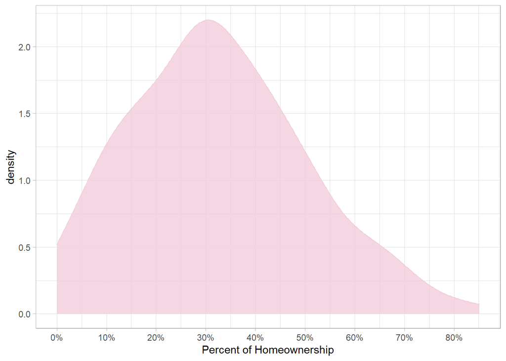

```r
ggplot(SD_tracts, aes(x = pct_own)) +
  geom_density(fill="#f1cddc", color="#f1cddc", alpha=0.8) +
  scale_x_continuous(name = "Percent of Homeownership",
                     breaks = seq(0, 1, by = 0.1),
                     labels = paste(seq(0, 100, by = 10), "%", sep = "")) +
  theme_light()
```

## Plot 11

This is a dot plot inspired by a combination of several examples. I think this graphic is one of the most clear, actually, but again I want to learn to edits the colors.

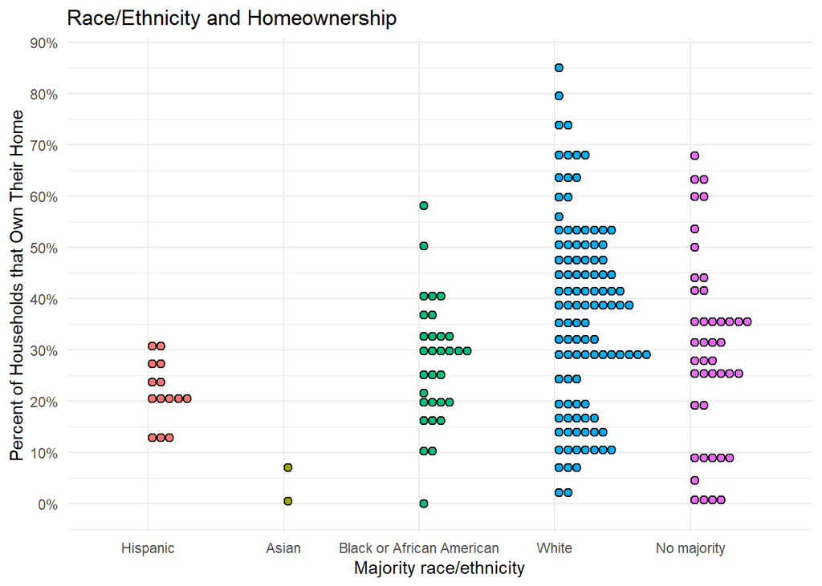

```r
ggplot(SD_tracts, aes(x = factor(majority_race_eth), y = pct_own, fill = factor(majority_race_eth))) +
    geom_dotplot(binaxis = "y", dotsize = 0.6) +
    scale_y_continuous(name = "Percent of Households that Own Their Home",
                     breaks = seq(0, 1, by = 0.1),
                     labels = paste(seq(0, 100, by = 10), "%", sep = "")) +
    scale_x_discrete(name = "Majority race/ethnicity",
                       labels = c("Hispanic",
                                  "Asian",
                                  "Black or African American",
                                  "White",
                                  "No majority")) +
    labs(fill = "Majority race/ethnicity") +
    scale_fill_discrete(name = "Majority race/ethnicity",
                       breaks=c("Hispanic",
                                  "Non-Hispanic Asian",
                                  "Black or African American",
                                  "White (Non-Hispanic)",
                                  "No majority"),
                         labels=c("Hispanic",
                                  "Non-Hispanic Asian",
                                  "Black or African American",
                                  "White (Non-Hispanic)",
                                  "No majority")) +
  labs(
    x='Majority race/ethnicity',
    y= 'Percent of Households that Own Their Home',
    title = 'Race/Ethnicity and Homeownership')+
  theme_minimal()
```

## Conclusion

Practicing representation skills through R has helped me to better read and interpret data. Because I stayed pretty close to the content in the tutorials, I think I need to become more creative and adventurous with these plots. There are graphic tweaks I am working on such as color, font and lineweights. I am extremely comfortable with doing this in Illustrator but would like to keep practicing the R code. I appreciate this assignment in conjunction with the Quant assignments.